# Recipe Book

```css
body {
    font-family: Courier;
    background-color: #ede5d8;
}

h1 {
    font-size: 24px;
    color: #8c593b;
    font-style: italic;
    text-decoration: underline;
    font-weight: bold;
}

h2, h3 {
    font-size: 20px;
    color: #5e6646;
    font-style: italic;
    text-decoration: underline;
    font-weight: bold;

}

p {
    font-size: 16px;
    color: #6b4c41;
    font-family: Courier;
    background-color: #d8c4ab;

}
```

```r
library(magick)
```

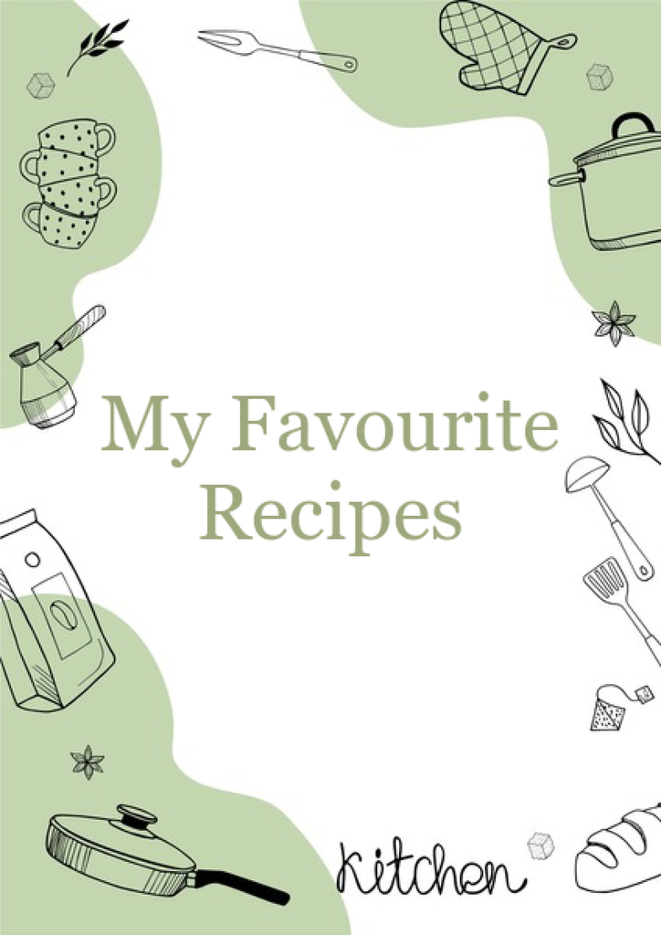

```r
# cover page
cover <- image_read("https://www.shutterstock.com/image-vector/recipe-cards-culinary-book-blank-600nw-2316202567.jpg") %>%
  image_annotate(text = "My Favourite\nRecipes",
                 size = 50,
                 color = "#9da87d",
                 gravity = "center",
                 font = "Georgia")

# Resizing
cover_resized <- cover %>%
  image_scale("2000x3000")

# Write the modified cover page image to a file
image_write(cover_resized, "cover.png")

#salad pictures
salad1 <-image_read("https://media.istockphoto.com/id/1338942257/photo/caprese-salad.jpg?s=612x612&w=0&k=20&c=NuHpJ-tnxy4oNAfEUJnB9cpYtEL2rN0ha9pJcLhcxXI=")%>%
  image_scale(500)

salad2 <-image_read("https://media.istockphoto.com/id/1342279242/photo/caprese-salad.jpg?s=612x612&w=0&k=20&c=7YmTZiDbQeSwmjhpgYSNv-UkVAwBv1xTUkA6taZrZhk=")%>%
  image_scale(500)

#combining/saving
salad3 <- c(salad1, salad2) %>%
  image_append

image_write(salad3, "salad.png")

#curry pictures
curry1 <-image_read("https://media.istockphoto.com/id/1140580445/photo/thai-green-curry.jpg?s=612x612&w=0&k=20&c=55r_mPreDyGcNLQPXzK9PAC2m8DXU1uN_9t4Zw_q8dU=")%>%
  image_scale("x500")

curry2 <-image_read("https://media.istockphoto.com/id/1209168283/photo/homemade-spicy-thai-coconut-green-curry.jpg?s=612x612&w=0&k=20&c=Fq3cuSiITcHlzKxkAr82eE896XdfU51cQhbUIePU0wY=")%>%
  image_scale("x500")

#combining/saving
curry3 <- c(curry1, curry2) %>%
  image_append

image_write(curry3, "curry.png")

#pizza pictures
pizza1 <-image_read("https://media.istockphoto.com/id/910195988/photo/pizza-margarita.jpg?s=612x612&w=0&k=20&c=ZPlovEsbFWJq6M3kLR98u0eo8NCYiFEuRjkMKQCwH40=")%>%
  image_scale("x500")

pizza2 <-image_read("https://media.istockphoto.com/id/1279000076/photo/freshly-baked-pizza-with-arugula-tomato-red-onion-and-mozzarella.jpg?s=612x612&w=0&k=20&c=rSoZDp5wdU5aSVVVc7lTNV9eWaA3KCza6FGNew6Diko=")%>%
  image_scale("x500")

#combining/saving
pizza3 <- c(pizza1, pizza2) %>%
  image_append

image_write(pizza3, "pizza.png")

#lasagne pictures
lasagne1 <-image_read("https://media.istockphoto.com/id/535851351/photo/lasagna-on-a-square-white-plate.jpg?s=612x612&w=0&k=20&c=Rg1K7z4NlWhy2qexaym_GJ0khcJFSJUJgToTN2cRspM=")%>%
  image_scale("x500")

lasagne2 <-image_read("https://media.istockphoto.com/id/543831374/photo/meat-lasagna.jpg?s=612x612&w=0&k=20&c=cLey-TcKmbqTQXbd86RDGnqKMaFfdCO5tJeFY8m61gI=")%>%
  image_scale("x500")

#combining/saving
lasagne3 <- c(lasagne1, lasagne2) %>%
  image_append

image_write(lasagne3, "lasagne.png")

#korma pictures
korma1 <-image_read("https://media.istockphoto.com/id/1124973765/photo/chicken-curry.jpg?s=612x612&w=0&k=20&c=YTjPGlfvT7pHiy1RX8ZcoizSdUEE9ocOAEF65H4QgJA=") %>%
  image_scale(500)

korma2 <-image_read("https://media.istockphoto.com/id/486741528/photo/chicken-korma.jpg?s=612x612&w=0&k=20&c=RAJHxmyYyF0EtH7cDdgnBH7SBjm_8kzUNfJ9fot933c=") %>%
  image_scale(500)

#combining/saving
korma3 <- c(korma1, korma2) %>%
  image_append

image_write(korma3, "korma.png")
```

# Caprese Salad

## Ingredients:

- Tomatoes (500g)
- Fresh mozzarella cheese (250g)
- Fresh basil leaves (a handful)
- Balsamic glaze (2 tablespoons)
- Olive oil (2 tablespoons)
- Salt and pepper (to taste)

## Instructions:

1. Slice the tomatoes and fresh mozzarella cheese into rounds.
2. Arrange the tomato and mozzarella slices on a plate, alternating with fresh basil leaves.
3. Drizzle with balsamic glaze and olive oil.
4. Season with salt and pepper to taste.

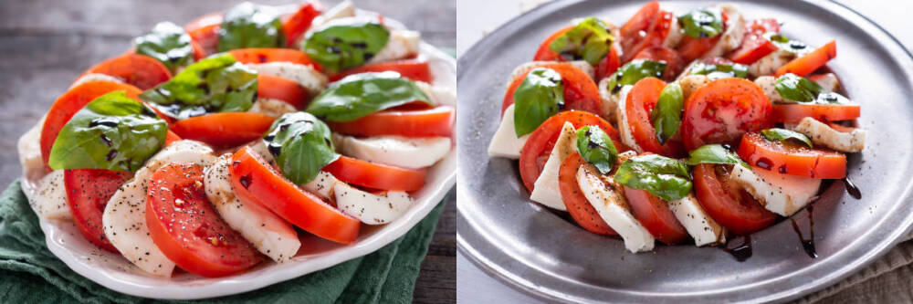

# Thai Green Curry

## Ingredients:

- Green curry paste (1 tablespoon)
- Coconut milk (1 can - 400ml)
- Mixed vegetables (such as bell peppers, zucchini, and carrots) (200g)
- Tofu or chicken, sliced (200g)
- Fish sauce (or soy sauce for vegetarian/vegan option) (2 tablespoons)
- Brown sugar (1 tablespoon)
- Fresh basil leaves for garnish
- Cooked rice for serving

## Instructions:

1. In a large pan, heat the green curry paste over medium heat for 1-2 minutes.
2. Pour in the coconut milk and stir until well combined with the curry paste.
3. Add the mixed vegetables and tofu/chicken to the pan. Cook until the vegetables are tender and the protein is cooked through.
4. Stir in the fish sauce (or soy sauce) and brown sugar. Simmer for a few more minutes.
5. Serve the Thai green curry hot over cooked rice. Garnish with fresh basil leaves.

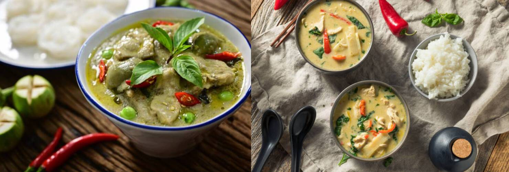

# Homemade Pizza

## Ingredients:

- Pizza dough (store-bought or homemade)
- Pizza sauce (approx. 200ml)
- Shredded mozzarella cheese (approx. 200g)
- Assorted toppings (such as pepperoni, bell peppers, mushrooms, and onions)
- Olive oil for brushing (2 tablespoons)

## Instructions:

1. Preheat the oven to 220°C
2. Roll out the pizza dough on a lightly floured surface to your desired thickness.
3. Transfer the rolled-out dough to a pizza pan or baking sheet lined with parchment paper.
4. Spread pizza sauce evenly over the dough, leaving a small border around the edges.
5. Sprinkle shredded mozzarella cheese over the sauce, then add your desired toppings.
6. Brush the edges of the pizza dough with olive oil for a golden crust.
7. Bake the pizza in the preheated oven for 10-15 minutes, or until the crust is golden brown and the cheese is bubbly.
8. Slice and serve the homemade pizza hot.

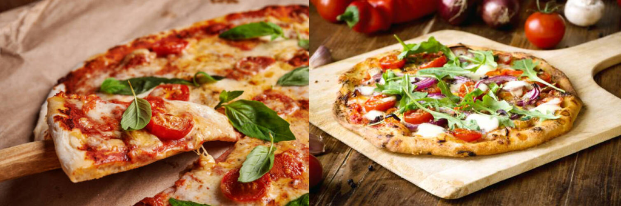

# Lasagne

## Ingredients:

- Lasagne sheets
- Ground beef (1kg)
- Onion, diced (1-2)
- Garlic, minced (3 cloves)
- Tomato paste (400g)
- Ricotta cheese (500g)
- Mozzarella cheese, shredded (500g)
- Parmesan cheese, grated (100g)
- Fresh basil leaves for garnish

## Instructions:

1. Preheat the oven to 190°C.
2. In a large skillet, cook the ground beef over medium heat until browned. Add diced onion and minced garlic, and cook until softened.
3. Stir in tomato sauce and simmer for 10-15 minutes.
4. In a separate bowl, mix together ricotta cheese, shredded mozzarella cheese, and grated Parmesan cheese.
5. Spread a thin layer of the meat sauce in the bottom of a baking dish. Place a layer of lasagne sheets on top.
6. Spread a layer of the cheese mixture over the lasagne sheets. Repeat the layers until all ingredients are used, ending with a layer of cheese on top.
7. Cover the baking dish with foil and bake in the preheated oven for 25-30 minutes.
8. Remove the foil and bake for an additional 10-15 minutes, or until the lasagne is bubbling and golden brown on top.
9. Let the lasagne cool for a few minutes before serving. Garnish with fresh basil leaves if desired.

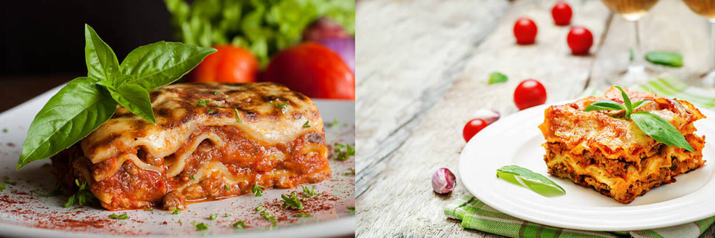

# Chicken Korma

## Ingredients:

- Vegetable oil (1 tablespoon)
- Onion, finely chopped (1)
- Garlic, minced (2 cloves)
- Grated ginger (1 tablespoon)
- Boneless, skinless chicken thighs or breasts, cut into bite-sized pieces (500g)
- Korma curry paste (1/4 cup)
- Coconut milk (1 cup)
- Chicken broth (1/2 cup)
- Plain yogurt (1/4 cup)
- Lemon juice (1 tablespoon)
- Salt and pepper
- Chopped cilantro for garnish
- Cooked rice or naan bread for serving

## Instructions:

1. Heat vegetable oil in a large skillet over medium heat. Add finely chopped onion, minced garlic, and grated ginger. Cook until softened and fragrant, about 5 minutes.
2. Add the chicken pieces to the skillet and cook until browned on all sides.
3. Stir in korma curry paste and cook for 1-2 minutes.
4. Pour in coconut milk and chicken broth. Bring to a simmer and let it cook for 15-20 minutes, or until the chicken is cooked through and the sauce has thickened.
5. Remove the skillet from heat and stir in plain yogurt and lemon juice. Season with salt and pepper to taste.
6. Serve the chicken korma hot over cooked rice or with naan bread.

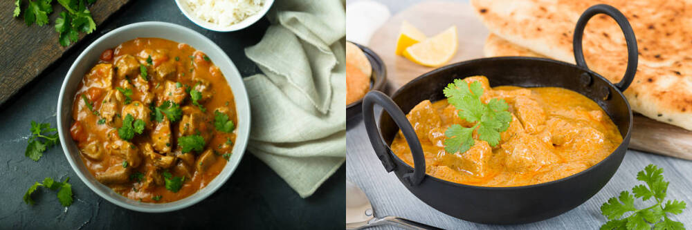